# Group 1 Project

## Load the libraries and data

### Set the factors

```r
treatment_pattern <- (rep(c("Untreated", "Treatment"), times = 9))
treatment <- factor(c(treatment_pattern))

donor_pattern <- c(rep("M24", times = 6), rep("M31", times = 6), rep("M32", times = 6))
donors <- factor(c(donor_pattern))
```

### Cbind the factors

```r
groups <- data.frame(sample = colnames(counts), treatment, donors)

cbind(groups,colnames(counts))
```

| sample | treatment | donors | colnames(counts) |
| --- | --- | --- | --- |
| CF_M24_EV1 | Untreated | M24 | CF_M24_EV1 |
| CF_M24_EVPA1 | Treatment | M24 | CF_M24_EVPA1 |
| CF_M24_EV2 | Untreated | M24 | CF_M24_EV2 |
| CF_M24_EVPA2 | Treatment | M24 | CF_M24_EVPA2 |
| CF_M24_EV3 | Untreated | M24 | CF_M24_EV3 |
| CF_M24_EVPA3 | Treatment | M24 | CF_M24_EVPA3 |
| CF_M31_EV1 | Untreated | M31 | CF_M31_EV1 |
| CF_M31_EVPA1 | Treatment | M31 | CF_M31_EVPA1 |
| CF_M31_EV2 | Untreated | M31 | CF_M31_EV2 |
| CF_M31_EVPA2 | Treatment | M31 | CF_M31_EVPA2 |

[output cut: 8 more lines]

## Part 1 – Exploratory Analysis

### 1. Visualize your library sizes.

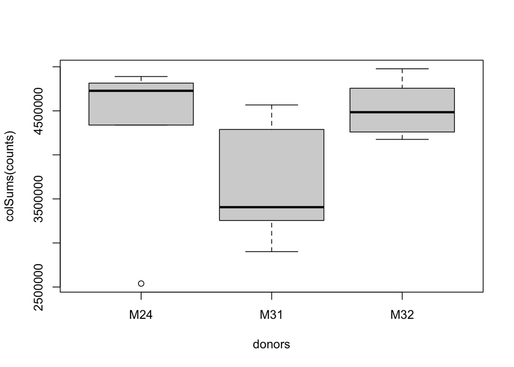

```r
boxplot(colSums(counts) ~ donors)
```

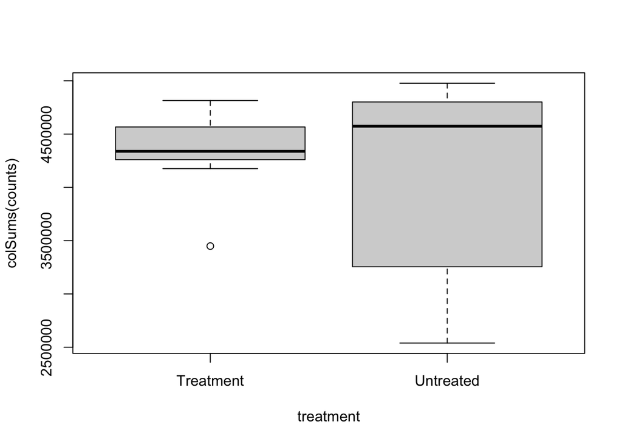

```r
boxplot(colSums(counts) ~ treatment)
```

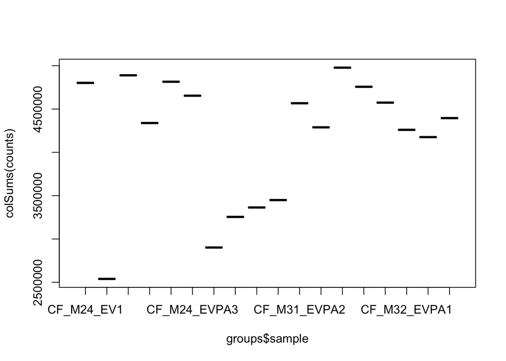

```r
boxplot(colSums(counts) ~ groups$sample)
```

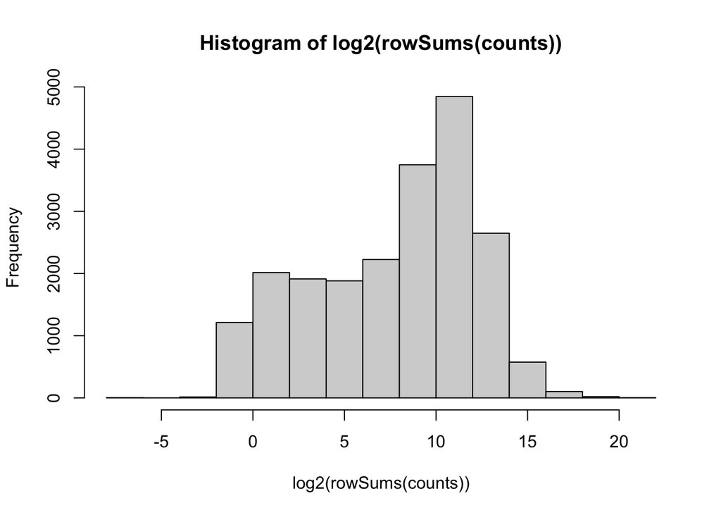

```r
hist(log2(rowSums(counts)))
```

### 3. Determine how many genes had zero counts and remove these genes (rows) from the data set. What does your count distribution look like before and after this?

```r
MinVals <- apply(counts, 1, min)
sum(MinVals == 0)
```

```
## [1] 24868
```

```r
Exp <- counts[MinVals > 0, ]
```

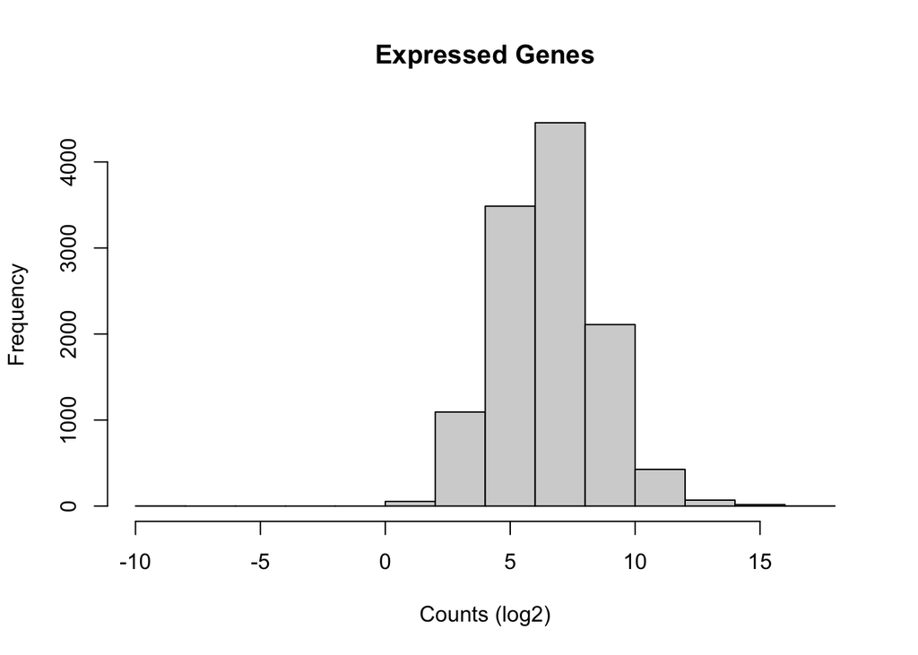

```r
ExpLog2 <- log2(Exp)
hist(rowMeans(ExpLog2), xlab = "Counts (log2)", main = "Expressed Genes")
```

### 4. Make a boxplot of log2 raw counts after removing all genes that had zero counts.

Plot “raw” (our log2 transformed) sample counts

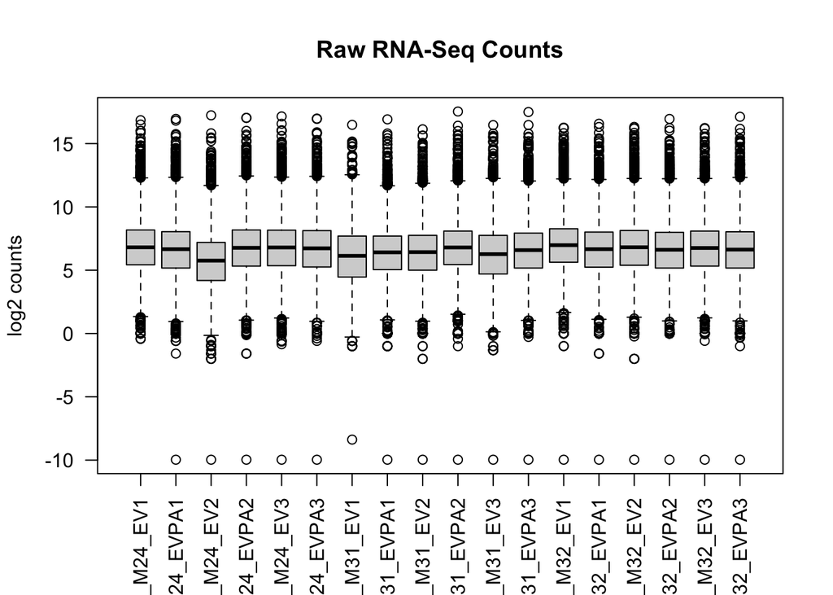

```r
boxplot(ExpLog2, ylab = "log2 counts", main = "Raw RNA-Seq Counts", las = 2)
```

### 5. Make a Cluster Dendrogram of the raw data.

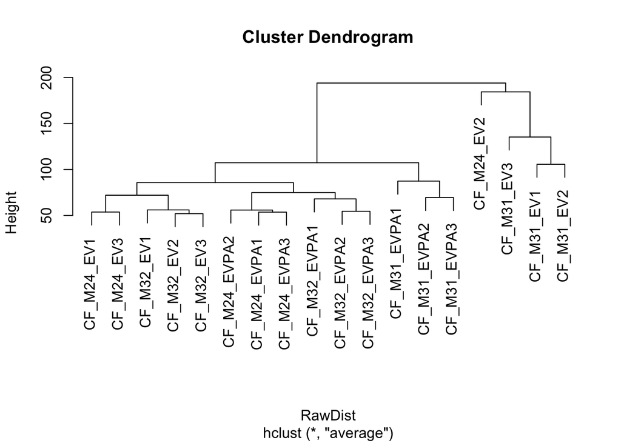

```r
RawDist <- dist(t(ExpLog2), method = "euclidean")
plot(hclust(RawDist, method = "average"))
```

Simple normalization

```r
SampleMedians <- apply(ExpLog2, 2, median) # Find the median value of each column - 2 means column
GrandMedian <- mean(SampleMedians) # Take the average of those
CorrectionFactors <- GrandMedian - SampleMedians # Calculate correction factor to apply to data
CorrectionFactors
```

```
##   CF_M24_EV1 CF_M24_EVPA1   CF_M24_EV2 CF_M24_EVPA2   CF_M24_EV3 CF_M24_EVPA3
## -0.219473027 -0.070329588  0.832994393 -0.180937605 -0.206533972 -0.140038560
##   CF_M31_EV1 CF_M31_EVPA1   CF_M31_EV2 CF_M31_EVPA2   CF_M31_EV3 CF_M31_EVPA3
##  0.453085963  0.178490959  0.157864308 -0.206533972  0.321095354  0.002904366
##   CF_M32_EV1 CF_M32_EVPA1   CF_M32_EV2 CF_M32_EVPA2   CF_M32_EV3 CF_M32_EVPA3
## -0.389398029 -0.071942790 -0.225924944 -0.026827949 -0.167005607 -0.041489298
```

These correction factors will align the medians of all of our samples This changes our counts just enough to correct for variability between samples/groups without loosing any actual effects of changes in gene expression.

Loop through each column (sample) and fill in medians adjusted with sample correction factor

```r
ExpNorm <- ExpLog2

for(col in colnames(ExpNorm)){
  ExpNorm[, col] <- ExpLog2[, col] + CorrectionFactors[col]
}
```

### 6. Do a simple normalization of your data and visualize your normalized data with a boxplot of log2 raw counts and a cluster dendrogram. Did normalization change anything?

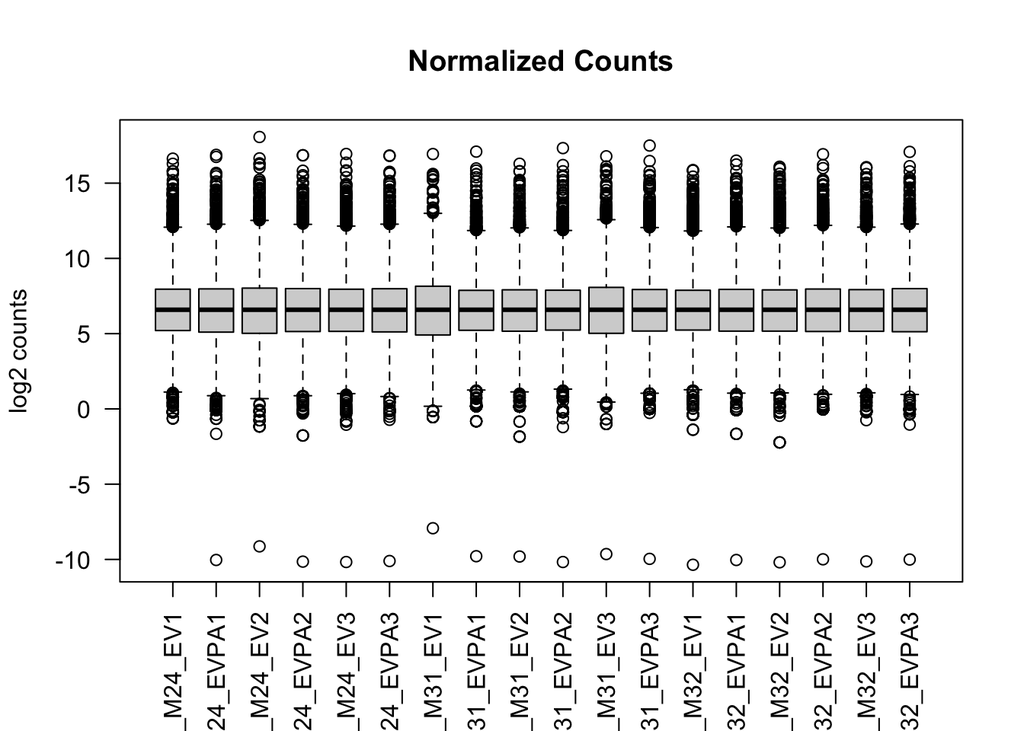

```r
boxplot(ExpNorm, ylab = "log2 counts", main = "Normalized Counts", las = 2)
```

Cluster dendrogram of normalized data

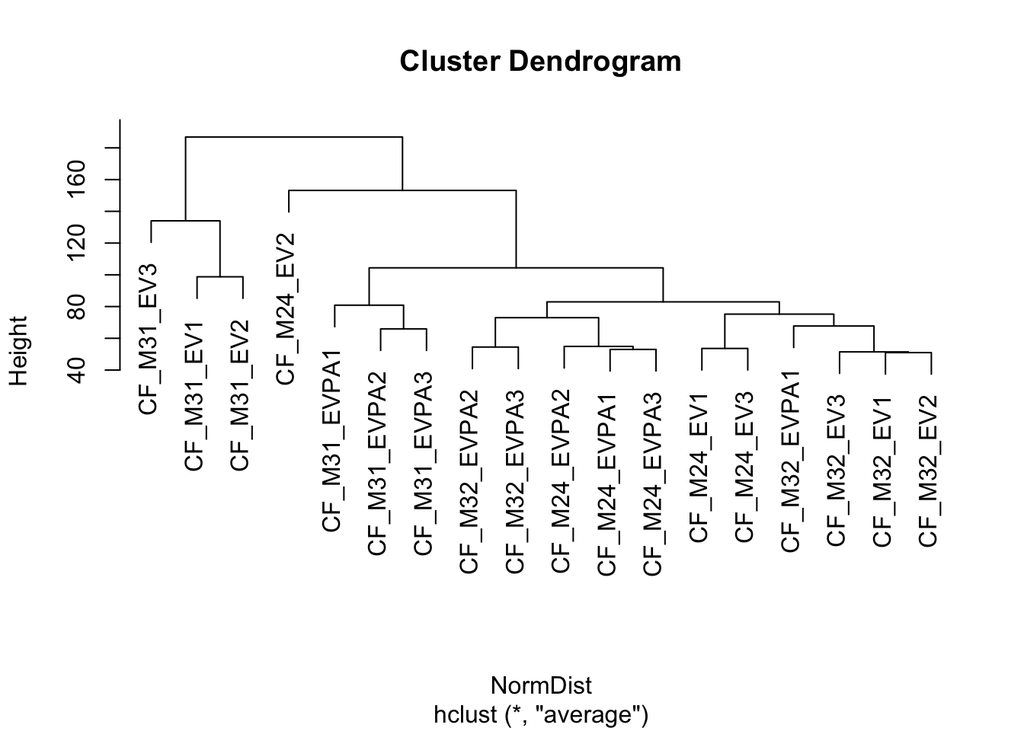

```r
NormDist <- dist(t(ExpNorm), method = "euclidean")
plot(hclust(NormDist, method = "average"))
```

### 7. Make a PCA plot and use color to highlight groups

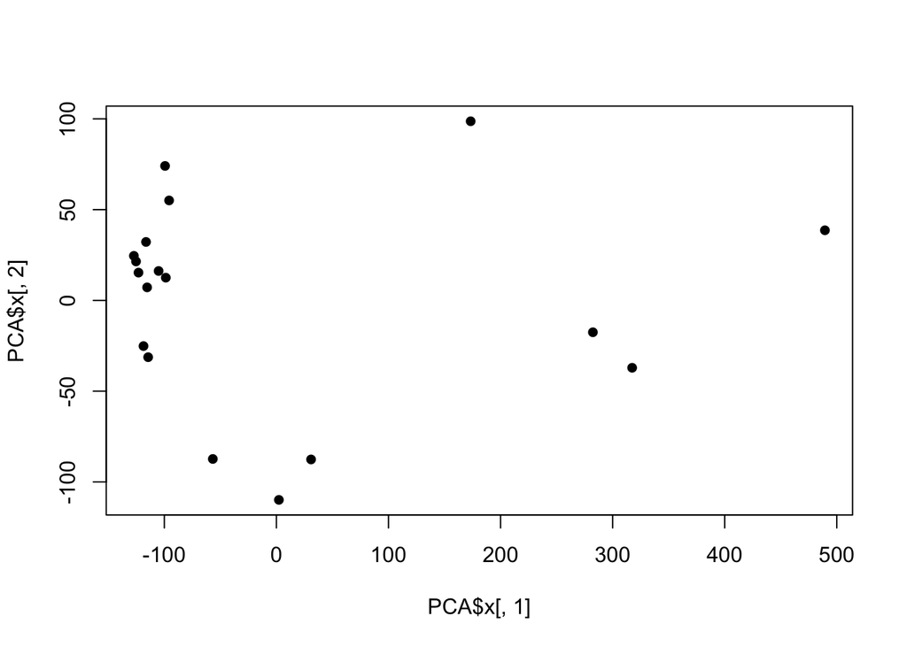

```r
PCA <- prcomp(t(NormDist))
plot(PCA$x[ , 1], PCA$x[ , 2], pch = 16)
```

By donor

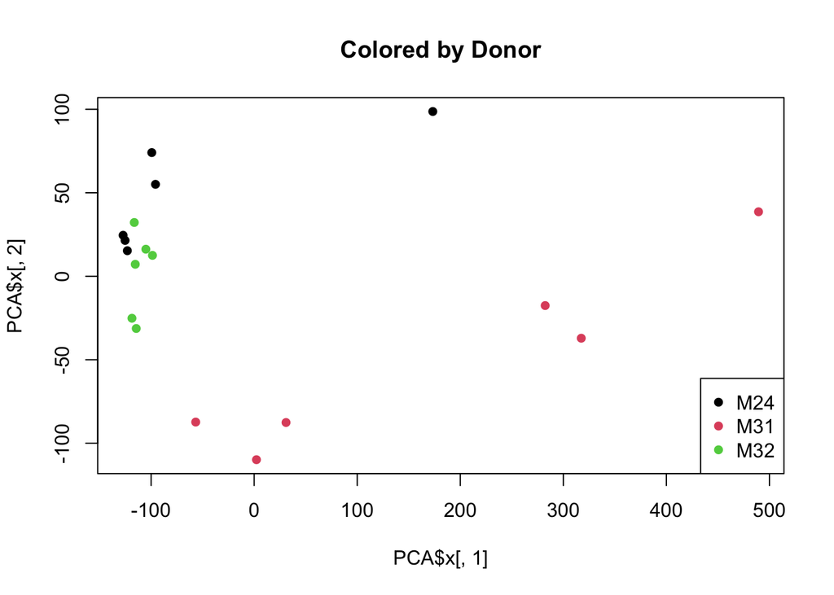

```r
plot(PCA$x[ , 1], PCA$x[ , 2], pch = 16, col = donors,
     main = "Colored by Donor")
legend("bottomright", legend = unique(donors), pch = 16, col = unique(donors))
```

By treatment

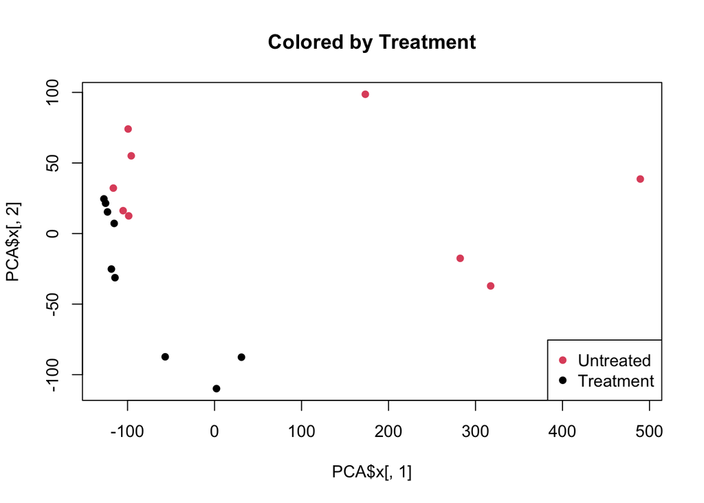

```r
plot(PCA$x[ , 1], PCA$x[ , 2], pch = 16, col = treatment,
     main = "Colored by Treatment")
legend("bottomright", legend = unique(treatment), pch = 16, col = unique(treatment))
```

## Part 2. Differential Gene Expression with edgeR

## When creating the DGEList object, include the gene annotation information from the “Annotations.csv” file as your argument in “genes =”

```r
annotations <- read.csv(file = "Annotations.csv",
                     header = TRUE,
                     row.names = 1)
DGE <- DGEList(counts = counts, remove.zeros = TRUE, genes = annotations)
```

```
## Removing 15373 rows with all zero counts
```

## Include both treatment and donor in your experimental design matrix.

```r
design <- model.matrix(~ 0 + treatment + donors, data = counts)
rownames(design) <- colnames(DGE)
design
```

```
##              treatmentTreatment treatmentUntreated donorsM31 donorsM32
## CF_M24_EV1                    0                  1         0         0
## CF_M24_EVPA1                  1                  0         0         0
## CF_M24_EV2                    0                  1         0         0
## CF_M24_EVPA2                  1                  0         0         0
## CF_M24_EV3                    0                  1         0         0
## CF_M24_EVPA3                  1                  0         0         0
## CF_M31_EV1                    0                  1         1         0
## CF_M31_EVPA1                  1                  0         1         0
## CF_M31_EV2                    0                  1         1         0
## CF_M31_EVPA2                  1                  0         1         0
## CF_M31_EV3                    0                  1         1         0
## CF_M31_EVPA3                  1                  0         1         0
## CF_M32_EV1                    0                  1         0         1
## CF_M32_EVPA1                  1                  0         0         1
## CF_M32_EV2                    0                  1         0         1
## CF_M32_EVPA2                  1                  0         0         1
## CF_M32_EV3                    0                  1         0         1
## CF_M32_EVPA3                  1                  0         0         1
## attr(,"assign")
## [1] 1 1 2 2
## attr(,"contrasts")
## attr(,"contrasts")$treatment
## [1] "contr.treatment"
##
## attr(,"contrasts")$donors
## [1] "contr.treatment"
```

Remove low expression genes

```r
keep <- filterByExpr(DGE, design, min.count = 10, min.total.count = 15)
DGE <- DGE[keep, ] # Keep genes that meet our threshold!
```

Take a look at the library sizes of each sample

```r
DGE$samples
```

|  | group | lib.size | norm.factors |
| --- | --- | --- | --- |
| CF_M24_EV1 | 1 | 4801371 | 1 |
| CF_M24_EVPA1 | 1 | 4338118 | 1 |
| CF_M24_EV2 | 1 | 2539254 | 1 |
| CF_M24_EVPA2 | 1 | 4814634 | 1 |
| CF_M24_EV3 | 1 | 4889045 | 1 |
| CF_M24_EVPA3 | 1 | 4653652 | 1 |
| CF_M31_EV1 | 1 | 2901319 | 1 |
| CF_M31_EVPA1 | 1 | 3448953 | 1 |
| CF_M31_EV2 | 1 | 3254947 | 1 |
| CF_M31_EVPA2 | 1 | 4566704 | 1 |

[output cut: 8 more lines]

Normalize for different library sizes (TMM, trimmed mean of M-values)

```r
DGE <- calcNormFactors(DGE) # Calculates normalization factors and adds them to our DGE object
DGE$samples
```

|  | group | lib.size | norm.factors |
| --- | --- | --- | --- |
| CF_M24_EV1 | 1 | 4801371 | 1.0070739 |
| CF_M24_EVPA1 | 1 | 4338118 | 0.9891045 |
| CF_M24_EV2 | 1 | 2539254 | 0.9618214 |
| CF_M24_EVPA2 | 1 | 4814634 | 0.9802355 |
| CF_M24_EV3 | 1 | 4889045 | 0.9838259 |
| CF_M24_EVPA3 | 1 | 4653652 | 0.9764507 |
| CF_M31_EV1 | 1 | 2901319 | 1.0140181 |
| CF_M31_EVPA1 | 1 | 3448953 | 1.0213859 |
| CF_M31_EV2 | 1 | 3254947 | 1.0846888 |
| CF_M31_EVPA2 | 1 | 4566704 | 1.0201235 |

[output cut: 8 more lines]

Calculate overall dispersion estimateGLMCommonDisp calculates within-group and between-group variability.

```r
DGE <- estimateGLMCommonDisp(DGE, design, verbose = TRUE)
```

```
## Disp = 0.13864 , BCV = 0.3723
```

Calculate dispersion trend based on gene abundance

```r
DGE <- estimateGLMTrendedDisp(DGE, design)
```

Calculate separate dispersion for each gene

```r
DGE <- estimateGLMTagwiseDisp(DGE, design)
```

Visualize dispersion

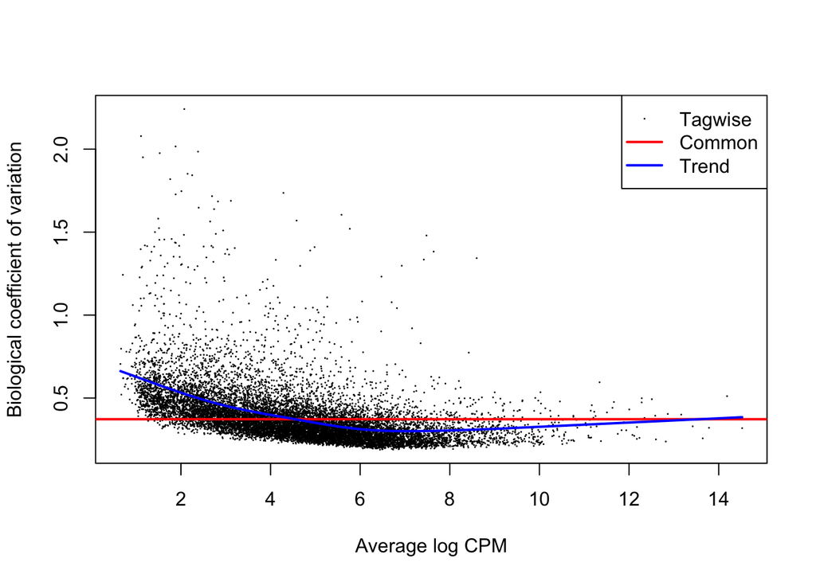

```r
plotBCV(DGE)
```

Let’s check that our normalization worked by plotting the log2(CPM) – counts per million

```r
CPM <- cpm(DGE, normalized.lib.sizes = TRUE, log = TRUE)
CPM <- as.data.frame(CPM)
```

Visualize normalized data

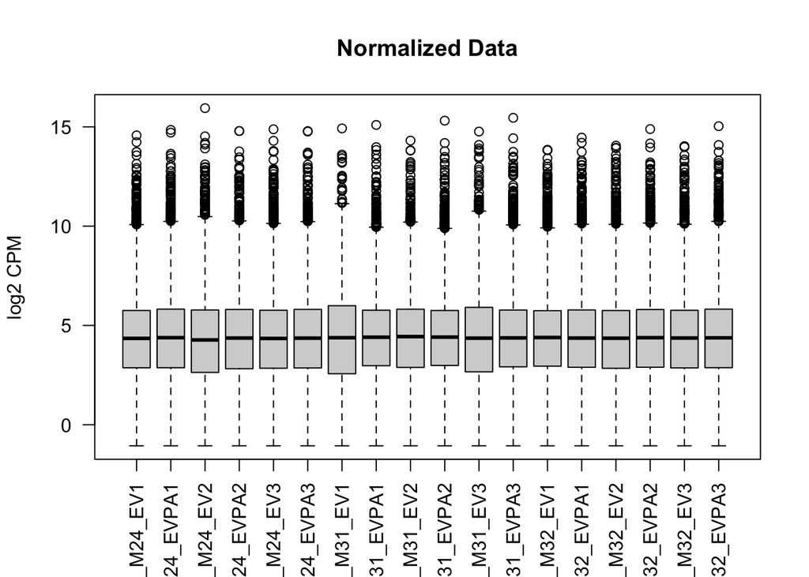

```r
boxplot(CPM, las = 2, ylab = "log2 CPM", main = "Normalized Data")
```

### Contrast Matrix

```r
contrast.matrix <- makeContrasts(PA_vs_Unt = treatmentTreatment - treatmentUntreated,
                                 levels = design)
```

## 3. When running the glmLRT function, be careful to use the correct name to specify the comparison of interest. For the purpose of this exercise, we are interested in the treatment effects.

Fit a gene-wise negative binomial generalized linear model

```r
fit <- glmFit(DGE, design, contrast = contrast.matrix)
lrt <- glmLRT(fit, contrast = contrast.matrix[,"PA_vs_Unt"])
topTags(lrt)
```

```
## Coefficient:  1*treatmentTreatment -1*treatmentUntreated
##                 ENTREZID  SYMBOL    logFC    logCPM       LR       PValue
## ENSG00000163735     6374   CXCL5 8.273419  9.974252 326.2474 6.311306e-73
## ENSG00000125538     3553    IL1B 6.839713  8.083009 267.9416 3.188065e-60
## ENSG00000131203     3620    IDO1 7.955039  3.863020 197.3261 8.005098e-45
## ENSG00000112096     6648    SOD2 3.804425 11.125940 183.0936 1.023291e-41
## ENSG00000038427     1462    VCAN 6.115405  6.254267 181.8779 1.885469e-41
## ENSG00000168685     3575    IL7R 4.350997  6.481631 175.9473 3.718268e-40
## ENSG00000173391     4973    OLR1 5.141068  4.918480 174.1794 9.045060e-40
## ENSG00000123610     7130 TNFAIP6 6.155642  6.589205 173.7613 1.116150e-39
## ENSG00000163739     2919   CXCL1 7.013255  5.866085 160.6594 8.120582e-37
## ENSG00000184557     9021   SOCS3 6.334366  5.544533 153.6593 2.749003e-35
##                          FDR
## ENSG00000163735 8.144110e-69
## ENSG00000125538 2.056940e-56
## ENSG00000131203 3.443260e-41
## ENSG00000112096 3.301138e-38
## ENSG00000038427 4.866019e-38
## ENSG00000168685 7.996754e-37
## ENSG00000173391 1.667392e-36
## ENSG00000123610 1.800350e-36
## ENSG00000163739 1.164311e-33
## ENSG00000184557 3.547314e-32
```

```r
de <- decideTests(lrt, adjust.method = "fdr")
summary(de)
```

```
##        1*treatmentTreatment -1*treatmentUntreated
## Down                                         2286
## NotSig                                       8540
## Up                                           2078
```